# Analysis Halloween Data

Sandra Tobon

27/03/2020

# 1 HALLOWEEN DATA

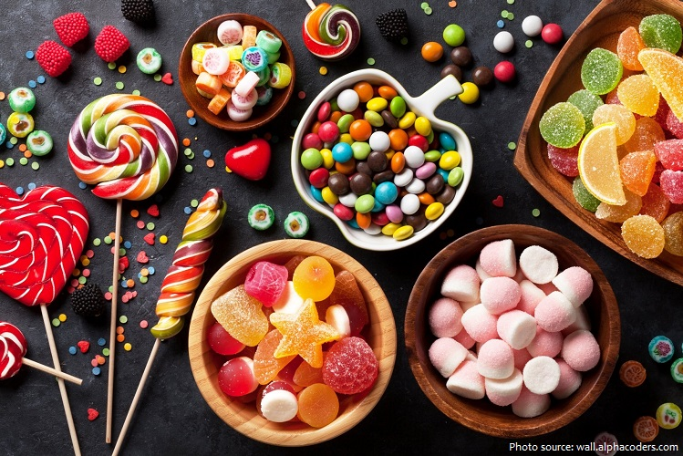

## 1.1 What is the dataset about?

Every year around the world but mainly in USA and Canada, is a poll that ask people about how if they **Join**, **Despair** or **Meh**, some general candies; the grade of conecction that they have with specifics famous person; some question about cultural and publicity things, and some personal questions.

For this exercise is only neccesary the information about the candies.

## 1.2 Data clean proccess

- Clean the age column
- Clean the country column, for this is very helpfull the states column. (2016 - 2017)
- Select the columns for the analysis
- Pivot longer (candies and the preferences)
- Add a year column in each data set.
- Add some columns that 2015 data set didn’t have.
- Unit the 3 data sets and filter some information without relation to a real candy

## 1.3 Solutions to the questions

1. Total number of candy ratings given across the three years

```r
halloween_candies %>%
  group_by(candies_food) %>%
  summarise(n_candies_ratings = n()) %>%
  summarise(total_candies_ratings = sum(n_candies_ratings))
```

| total_candies_ratings |
| --- |
| 118533 |

```r
halloween_candies %>%
    group_by(candies_food) %>%
    summarise(n_candies = n_distinct(candies_food)) %>%
    summarise(total_candies_analysis = sum(n_candies))
```

| total_candies_analysis |
| --- |
| 120 |

```r
halloween_candies %>%
  select(trick_themself, age) %>%
  filter(!is.na(trick_themself)) %>%
  group_by(trick_themself) %>%
  summarise(average_age = round(mean(age),0))
```

| trick_themself | average_age |
| --- | --- |
| No | 42 |
| Yes | 37 |

3. Candy bar revived the most of joy, despair and meh

```r
halloween_candies %>%
  filter(!is.na(preference_candies)) %>%
  group_by(candies_food, preference_candies) %>%
  summarise(total_votes = n()) %>%
  group_by(preference_candies) %>%
  filter(candies_food != "Any full-sized candy bar") %>%
  top_n(1)
```

| candies_food | preference_candies | total_votes |
| --- | --- | --- |
| Broken glow stick | DESPAIR | 755 |
| Kit Kat | JOY | 713 |
| Lollipops | MEH | 461 |

4. People rated Starburst as despair

```r
halloween_candies %>%
  filter(!is.na(preference_candies)) %>%
  filter(candies_food == "Starburst") %>%
  group_by(preference_candies) %>%
  summarise(total_starburst = n()) %>%
  filter(preference_candies == "DESPAIR")
```

| preference_candies | total_starburst |
| --- | --- |
| DESPAIR | 351 |

5. Most popular candy bar by this rating system for each gender in the dataset

```r
halloween_candies %>%
  filter(!c(gender == "Not ask" | is.na(preference_candies))) %>%
  group_by(gender, candies_food) %>%
  summarise(total_prefence = sum(puntuation)) %>%
  filter(candies_food != "Any full-sized candy bar") %>%
  top_n(1)
```

| gender | candies_food | total_prefence |
| --- | --- | --- |
| Female | Kit Kat | 202 |
| Female | Lindt Truffle | 202 |
| I'd rather not say | Kit Kat | 33 |
| Male | Kit Kat | 249 |
| Other | Twix | 26 |

```r
halloween_candies %>%
  filter(!is.na(preference_candies)) %>%
  group_by(year, candies_food) %>%
  summarise(total_prefence = sum(puntuation)) %>%
  filter(candies_food != "Any full-sized candy bar") %>%
  arrange(desc(total_prefence)) %>%
  top_n(1)
```

| year | candies_food | total_prefence |
| --- | --- | --- |
| 2017 | Kit Kat | 287 |
| 2016 | Kit Kat | 220 |
| 2015 | Kit Kat | 45 |

7. Most popular candy bar by this rating system for each country in the dataset

```r
halloween_candies %>%
  filter(!c(year == 2015 | is.na(preference_candies))) %>%
  group_by(country, candies_food)  %>%
  summarise(total_prefence = sum(puntuation)) %>%
  filter(candies_food != "Any full-sized candy bar") %>%
  arrange(desc(total_prefence)) %>%
  top_n(1)
```

| country | candies_food | total_prefence |
| --- | --- | --- |
| USA | Kit Kat | 314 |
| Canada | Tolberone something or other | 124 |
| UK | Rolos | 32 |
| UK | Tolberone something or other | 32 |
| Germany | Butterfinger | 8 |
| Japan | Kit Kat | 7 |
| Japan | Nestle Crunch | 7 |
| Japan | Reese’s Peanut Butter Cups | 7 |
| Japan | Twix | 7 |
| Netherlands | Tolberone something or other | 6 |

[output cut: 623 more lines]